# ch04 - Modeling Visualisation

2020-05-15T11:10:39+09:00

## 개요

> A picture is worth a thousand words — English Language Adage The simple graph has brought more information to the data analyst’s mind than any other device. — John Tukey

한장의 그림이 수천단어보다 가치가 있다는 영어속담과, 명료한 시각화가 데이터분석가에게 다른 어떤 도구보다 더 많은 정보를 제공한다는 유명한 데이터 과학자의 조언. 핵심은 시각화이다.

본 장에서는 `ggplot2` 패키지를 활용한 시각화를 먼저 보여줄 것이다. 먼저 간단하게 `ggplot2` 패키지에 소개하자면 `Grammar of Graphics`[^1]의 철학을 담아서 `R` 생태계에서 유명한 학자 중, `Hadley Wickham`에 의해 주도적으로 개발되었다. 그래프에도 문법이 있다는 패키지의 철학 아래, `R`의 시각화는 괄목할만한 발전을 이루었고 이는 `R`의 대중화에도 큰 영향을 끼쳤다.

보통 시각화라고 하면 탐색적 자료 분석에 시각화를 많이 의미할 수도 있다. 그런데, 모델링 결과 또는 통계적인 결과를 시각화로 보여줄 수 있는 능력을 갖추는 것은 데이터분석가로써 한번 더 도약할 수 있다.

오늘 포스트는 이러한 주제에 맞춰서 다루도록 한다. 주요 이론적인 내용은 `Hadley Wickham`의 `R for Data Science`를 참고했다.

## II. 모델의 정의

통계에서 모델은 무엇일까? 또는 통계에서 모델의 역할은 무엇일까? 학자마다, 또는 주어진 환경에 따라 다르게 정의될 수도 있지만,

기본적으로 `모델은 데이터의 특유의 알고리즘을 통해 일반적인 패턴을 가장 잘 요약해주는 일종의`summary`와 같은 기능`이다라고 정의할 수 있다.

보통 모델이 `true` or `not true` 이렇게 인식될 수도 있다. 그러나, 모델은 `true` or `not true`로 인식되기 보다는 `useful` or `not useful`로 판단하는 것이 좋다. 즉, 쓸만한 모형을 찾는 과정이 `modeling`이라고 할 수 있겠다.

## III. 모델링 시각화

모형 학습을 위해서 필요한 필수 패키지를 설치한다.

```r
library(tidyverse)
library(modelr)
library(moderndive)
options(na.action = na.warn)
```

### (1) Sample 데이터 추출

- `evals` 데이터에서 20개 정도의 데이터만 추출합니다.

```r
set.seed(1234) # 재현성
sample_20 <- evals %>%
  sample_n(20) %>%
  select(bty_avg, score)
```

### (2) 250개의 모형

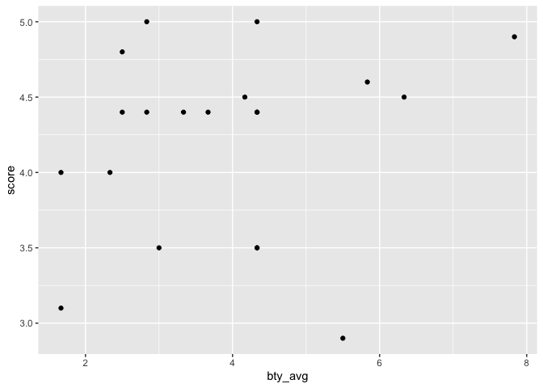

```r
ggplot(sample_20, aes(x = bty_avg, y = score)) +
  geom_point()
```

- 데이터를 보면, 우상향으로 데이터가 모여 있는 것을 볼 수 있다.
- 이 때, 양변수가 만나는 점을 설명할 수 있는 모형을 만들어보자.
- 보통 이러한 관계를 선형 관계라고 표현한다.
  $$y = a_0 + a_x \times x$$

위 데이터에 접하는 모형 250개를 만들어 보자.

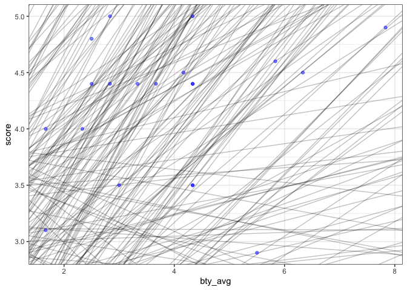

```r
models <- tibble(
  a1 = runif(250, 0.5, 4),
  a2 = runif(250, -.5, 1)
)

ggplot(sample_20, aes(x = bty_avg, y = score)) +
  geom_abline(aes(intercept = a1, slope = a2), data = models, alpha=1/4) +
  geom_point(color = "blue", alpha = 2/4) +
  theme_bw()
```

- 위 모형에서 보는 것처럼 굉장히 다양한 모형을 만들면서 최적의 모형을 찾는 고정이 모형이다.

### (3) 최적의 모형 찾기

최적의 모형은 어떻게 찾을 수 있을까?

최적의 모형을 찾으려면 `ggplot2` 패키지 내 `geom_smooth()`를 사용할 수 있다.

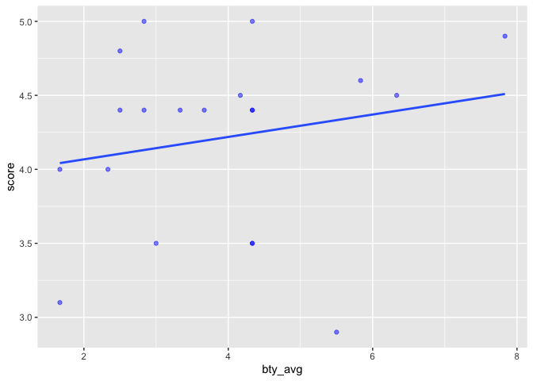

```r
ggplot(sample_20, aes(x = bty_avg, y = score)) +
  geom_point(color = "blue", alpha = 2/4) +
  geom_smooth(method = "lm", se=FALSE)
```

### (4) Computing Distance

```r
model_1 <- function(a, data) {
  a[1] + data$bty_avg * a[2]
}
```

```r
measure_distance <- function(mod, data) {
  diff <- data$score - model_1(mod, data)
  sqrt(mean(diff^2))
}

measure_distance(c(3, 2), sample_20)
```

```
## [1] 7.23253
```

### (5) All model dist

이제 전체 데이터와 모형간의 `거리`를 계산한다.

```r
all_model_dist <- function(a1, a2) {
  measure_distance(c(a1, a2), sample_20)
}

models2 <- models %>%
  mutate(dist = purrr::map2_dbl(a1, a2, all_model_dist))

models2 %>% head(5)
```

```
## # A tibble: 5 x 3
##      a1     a2  dist
##   <dbl>  <dbl> <dbl>
## 1 0.640  0.699 1.42
## 2 1.27  -0.461 4.85
## 3 3.34   0.260 0.666
## 4 2.34   0.732 1.53
## 5 3.70   0.317 1.00
```

### (6) Best 5 model

위 데이터를 근거로 가장 좋은 모델 5개를 찾는 그래프를 작성한다.

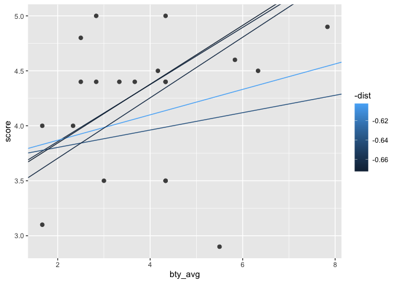

```r
ggplot(sample_20, aes(x = bty_avg, y = score)) +
  geom_point(size = 2, colour = "grey30") +
  geom_abline(
    aes(intercept = a1, slope = a2, colour = -dist),
    data = filter(models2, rank(dist) <= 5)
  )
```

- 위 그래프는 주어진 데이터에서 가장 좋은 모형 5개를 확인할 수 있다.

### (7) 최적의 모형 찾기

- 이제 `optim()` 함수를 활용해서 최적의 기울기와 상수를 찾아보도록 한다.

```r
best <- optim(c(0, 0), measure_distance, data = sample_20)

best$par
```

```
## [1] 3.91539624 0.07585949
```

기울기와 상수를 적용하여 다시 `ggplot2` 그래프를 작성한다.

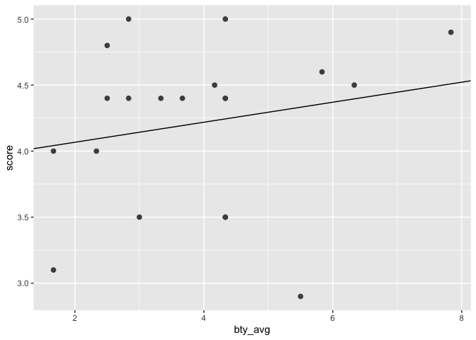

```r
ggplot(sample_20, aes(bty_avg, score)) +
  geom_point(size = 2, colour = "grey30") +
  geom_abline(intercept = best$par[1], slope = best$par[2])
```

- 실제로 `lm` 함수를 활용해여 기울기와 상수를 구해보자.

```r
lm_mod <- lm(score ~ bty_avg, data = sample_20)

coef(lm_mod)
```

```
## (Intercept)     bty_avg
##  3.91595907  0.07572129
```

- 실제로 `best`에서 추출한 것과, `lm` 함수를 사용한 값이라 동일한 것을 확인할 수 있다.

## IV. 결론

- 이번 포스트의 목적은 `ggplot2` 패키지를 활용하여 최적의 모형을 찾는 과정을 살펴 봤다.
- 시각화는 이렇게 모형을 찾는 과정도 넣을 수 있는데, 이러한 시각화를 활용하면 보다 효율적으로 선형회귀 모형에 대해 설명을 할 수 있다.

## V. Reference

Grolemund, G., & Wickham, H. (n.d.). R for Data Science. Retrieved from https://r4ds.had.co.nz/

[^1]: Hadley Wickham이 작성한 ggplot2 패키지에 관한 논문을 읽어보는 것을 제안한다. “The Layered Grammar of Graphics”, http://vita.had.co.nz/papers/layered-grammar.pdf